# Seasonal Models

Nik Bear Brown

In this lesson we’ll learn the how to implement Seasonal Models in R.

# Additional packages needed

To run the code you may need additional packages.

- If necessary install the followings packages.

`install.packages("ggplot2");`  
`install.packages("forecast");`  
`source(url("http://lib.stat.cmu.edu/general/tsa2/Rcode/itall.R"))`

```r
library(ggplot2)
library(forecast)
source(url("http://lib.stat.cmu.edu/general/tsa2/Rcode/itall.R"))
```

```
##   itall has been installed
```

# Data

We will be using U.S. Department of the Interior monthly flow data for the Colorado River. see http://www.usbr.gov/lc/region/g4000/NaturalFlow/documentation.html

```r
data_url <- 'http://nikbearbrown.com/YouTube/MachineLearning/M11/colorado_river.csv'
data<-read.csv(url(data_url))
head(data)
```

```
##   month year      flow
## 1     1   71  26635.42
## 2     2   71  21825.23
## 3     3   71  36031.57
## 4     4   71  43874.54
## 5     5   71  90616.44
## 6     6   71 146125.61
```

```r
names(data)
```

```
## [1] "month" "year"  "flow"
```

# Seasonal Models

When there are patterns that repeat over known, fixed periods of time (i.e. day, week, month, quarter, year, etc.) within the data set it is considered to be seasonal variation. One has a model for the periodic fluctuations based on knowledge of the domain.

The seasonal ARIMA model incorporates both non-seasonal and seasonal factors in a multiplicative model. In a seasonal ARIMA model, seasonal parameters predict xt using data values and errors at times with lags that are multiples of S (the span of the seasonality). Before we model for a given data set, one must have an initial guess about the data generation process, that is the span of the seasonality (i.e.day, week, month, quarter, year, etc.)

# Seasonal Models in R

Here we are using an ARIMA model to identify seasonality trends by looking for signficant seasonal differences.

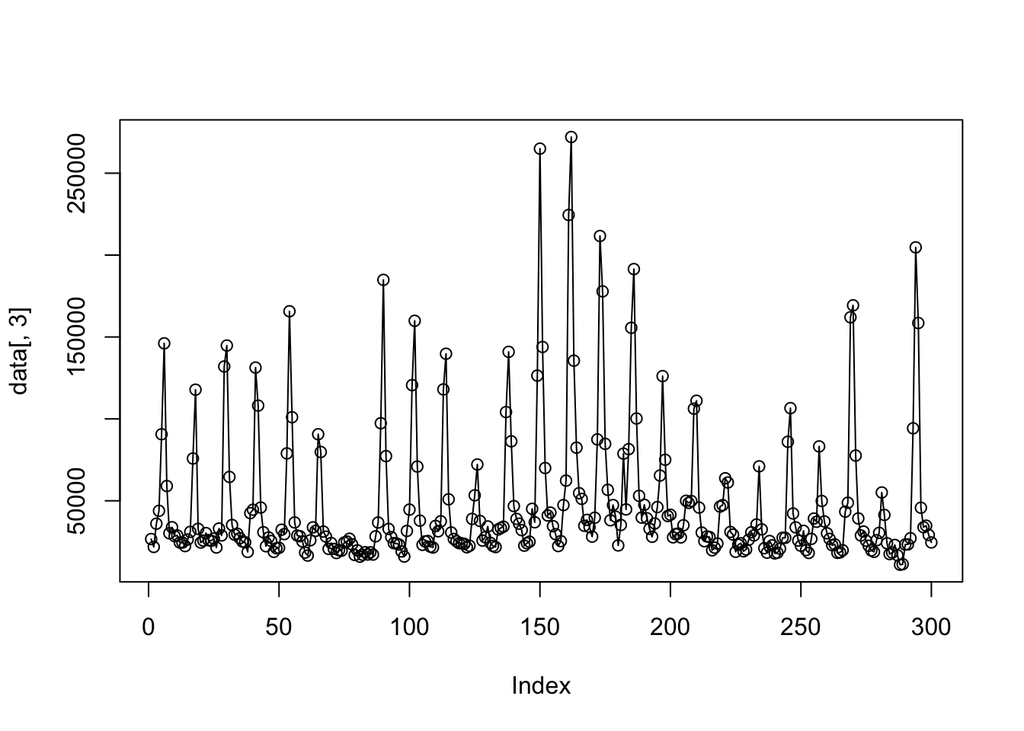

```r
plot(data[,3], type='o')
```

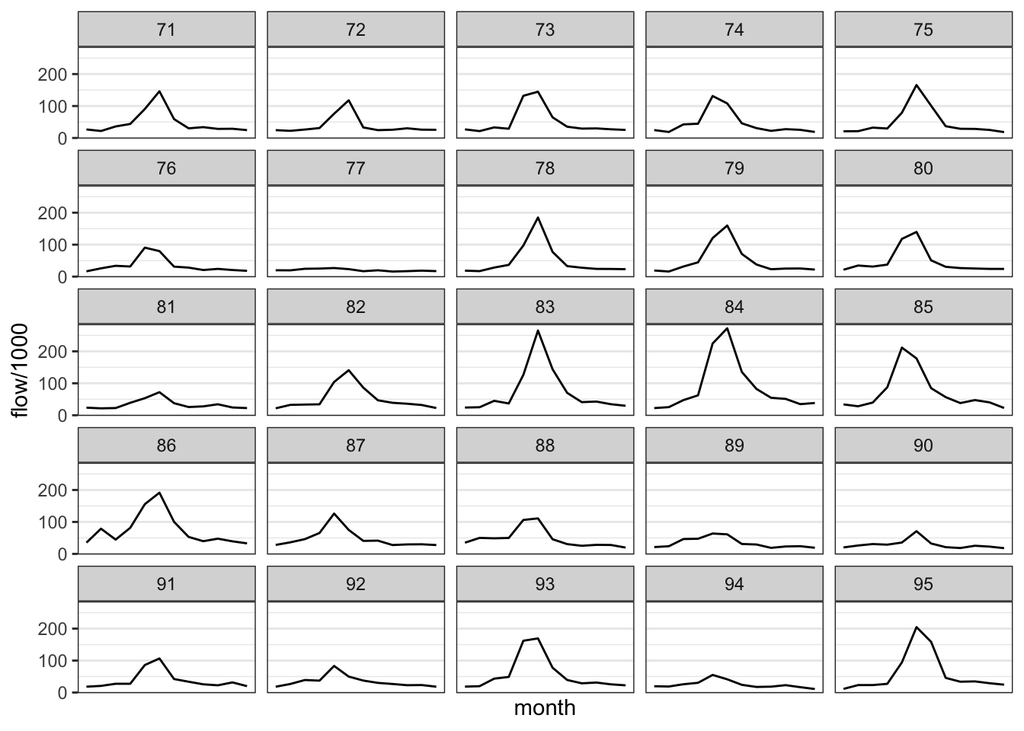

```r
#  it is difficult to identify seasonality trends here
# So,aggregate the data by month to better understand this trend
ggplot(data, aes(x=month, y=flow/1000))+
  stat_summary(geom = 'line', fun.y='mean')+             # take the mean of each month
  scale_x_discrete(breaks=seq(1,12,1), labels=seq(1,12,1))+
  theme_bw()+ # add a little style
  facet_wrap(~year) # visualize year by year
```